# Data Structures in R

Thomas Koentges

10/15/2020

# 1. Basics

R is like a fast calculator

```r
232047294879347 * 242424 / 12313 + 2
```

```
## [1] 4.568654e+15
```

In R `<-` is used to assign a value to a variable. You can also use `=`.

```r
test_variable <- 232047294879347 * 242424 / 12313 + 2
test_variable
```

```
## [1] 4.568654e+15
```

You can use `rm() to remove a variable or object.

```r
test_variable
```

```
## [1] 4.568654e+15
```

```r
rm(test_variable)
test_variable = 2
test_variable
```

```
## [1] 2
```

You do not have to remove to update or change the variable and you can change the variable using it’s own value.

```r
test_variable <- test_variable * test_variable
test_variable
```

```
## [1] 4
```

Aside from Base R functions, you can include third party functions, objects, and data via libraries

```r
# install.packages("tidyverse")
# This without the leading # would be the way to install a library.
# A line with a leading # is ignored by R.
# I have done so, because I do not want to install a package, already installed on my computer.
# You only have to use the install.packages() function once on each new system
# or after upgrading your R version.

# You can also use those #-lines to comment your code
# if you are using RStudio have a look what happens when you
# start a line with # and finish the line with ####
# This feature of RStudio helps you to organise your code.
library(tidyverse)
```

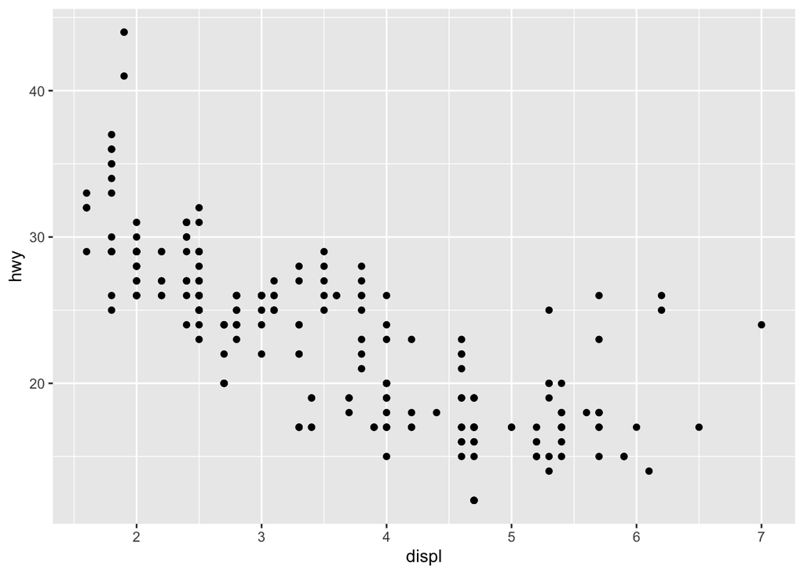

```r
mpg %>% ggplot(aes(displ,hwy)) + geom_point()
```

```r
# you do not need to understand the above code yet, just understand that we are using an external library
```

The tidyverse package is a library that contains a lot of useful features and it is the package, I use in almost every R programme.  
You can also generate your own functions:

```r
myFunction <- function(x) {
  result <- x + 2
  return(result)
}
myFunction(15)
```

```
## [1] 17
```

But before we make it anymore complicated than this, let’s have a look at the different data types and structures R has to offer.

# 2. R’s Data Types

The datatype of each variable is inferred:  
Logical is either `TRUE` or `FALSE`.

```r
variable <- FALSE
class(variable)
```

```
## [1] "logical"
```

Numeric is a number that can include fractual parts, i.e. 2.34.

```r
variable <- 2.34
class(variable)
```

```
## [1] "numeric"
```

Integer is a whole number.

```r
variable <- 2L
variable
```

```
## [1] 2
```

```r
class(variable)
```

```
## [1] "integer"
```

##### Sidetrack

Integers are cheaper than Numerics:

```r
object.size(c(1L,2L,3L,4L,5L)) < object.size(c(1,2,3,4,5))
```

```
## [1] TRUE
```

Unless they are empty:

```r
object.size(numeric()) == object.size(integer())
```

```
## [1] TRUE
```

Then they are both 48bytes:

```r
object.size(numeric())
```

```
## 48 bytes
```

##### Back on track

You can also express complex numbers.

```
variable <- 3 + 2i
variable
class(variable)
```

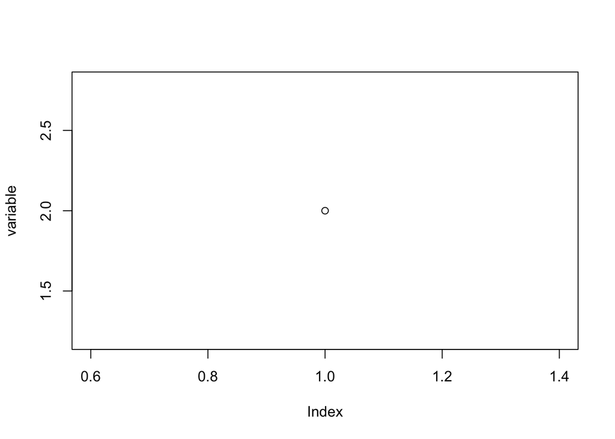

```r
plot(variable)
```

Strings are called characters in R.

```r
variable <- "hello world"
variable
```

```
## [1] "hello world"
```

```r
class(variable)
```

```
## [1] "character"
```

The last data type is `raw`. This refers to a byte stream.

```r
variable <- charToRaw(variable)
variable
```

```
##  [1] 68 65 6c 6c 6f 20 77 6f 72 6c 64
```

```r
class(variable)
```

```
## [1] "raw"
```

Raw objects are small. Empty raw objects are also 48bytes though:

```r
object.size(raw())
```

```
## 48 bytes
```

The types you will use most are characters, numeric, and logical.